# Reproducable Research Proj 1

Elizabeth Ellis

August 11, 2020

## Loading in Data

```r
unzip("activity.zip")
activity <- read.csv("activity.csv")
```

Next, we need to clean the data up. The dates need to be converted to the proper date formats. Weekdays are then calculated and added to the dataset

```r
activity$date <- as.POSIXct(activity$date, "%Y-%m-%d", tz = "EST")
weekday <- weekdays(activity$date)
activity <- cbind(activity,weekday)
```

Finally, let's load in the necessary R packages!

```r
require(ggplot2)
```

## What is the mean total number of steps taken per day?

1. Calculate the total number of steps taken per day

```r
activity_total_steps <- with(activity, aggregate(steps, by = list(date), FUN = sum, na.rm = TRUE))
names(activity_total_steps) <- c("date", "steps")
```

2. Create a histogram of the total number of steps taken per day

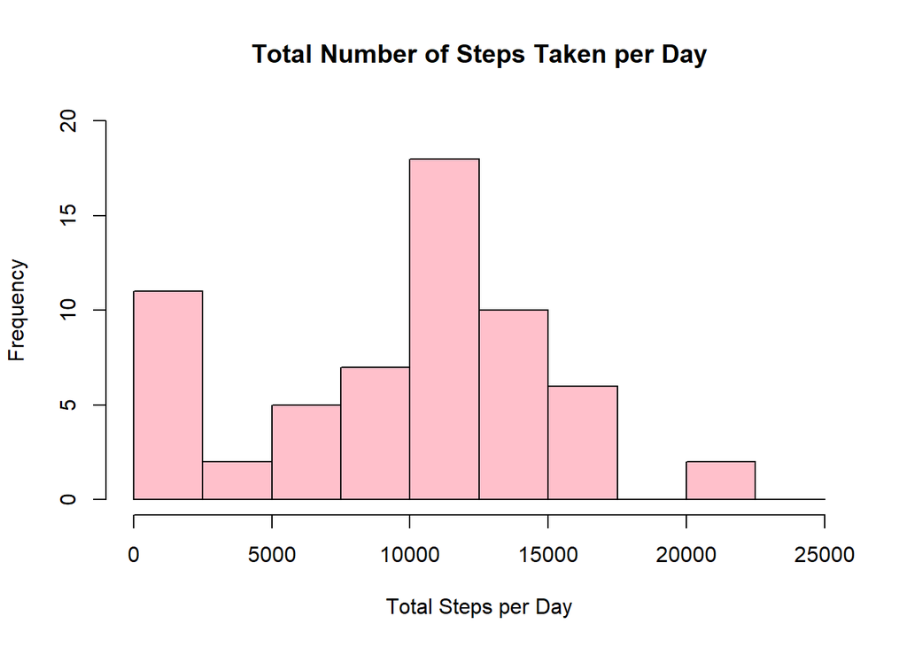

```r
hist(activity_total_steps$steps, main = "Total Number of Steps Taken per Day", xlab = "Total Steps per Day", col = "pink", ylim = c(0,20), breaks = seq(0,25000, by=2500))
```

3. Calculate and report the mean and median of the total number of steps taken per day

```r
mean1 <- mean(activity_total_steps$steps)
median1 <- median(activity_total_steps$steps)
paste("The mean number of steps taken per a day is", mean1)
```

```
## [1] "The mean number of steps taken per a day is 9354.22950819672"
```

```r
paste("The median number of steps taken per a day is", median1)
```

```
## [1] "The median number of steps taken per a day is 10395"
```

## What is the average daily activity pattern?

1. Make a time series plot (i.e. type = "l") of the 5-minute interval (x-axis) and the average number of steps taken, averaged across all days (y-axis)

```r
average_daily_activity <- aggregate(activity$steps, by=list(activity$interval), FUN=mean, na.rm=TRUE)
names(average_daily_activity) <- c("interval", "mean")
```

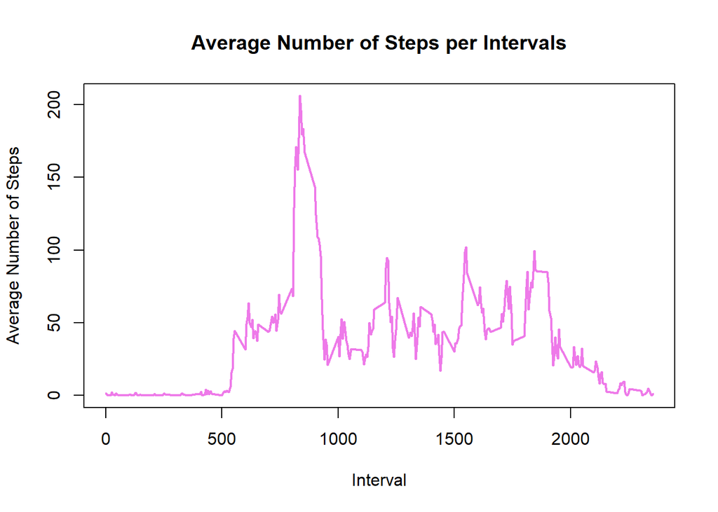

```r
plot(average_daily_activity$interval, average_daily_activity$mean, type = "l", col="orchid2", lwd = 2, xlab="Interval", ylab="Average Number of Steps", main="Average Number of Steps per Intervals")
```

2. Which 5-minute interval, on average across all the days in the dataset, contains the maximum number of steps?

```r
maxint <- average_daily_activity[which.max(average_daily_activity$mean), ]$interval
paste("Interval number", maxint, "has the maximum number of steps.")
```

```
## [1] "Interval number 835 has the maximum number of steps."
```

## Imputing Missing Values

1. Calculate and report the total number of missing values in the dataset (i.e. the total number of rows with NAs)

```r
misssteps <- sum(is.na(activity$steps))
paste("The number of missing values is", misssteps)
```

```
## [1] "The number of missing values is 2304"
```

2. Devise a strategy for filling in all of the missing values in the dataset. (Replace missing values with mean score)

```r
imputed_steps <- average_daily_activity$mean[match(activity$interval, average_daily_activity$interval)]
```

3. Create a new dataset with the missing values replaced by the mean

```r
activity_imputed <- transform(activity, steps = ifelse(is.na(activity$steps), yes = imputed_steps, no = activity$steps))
total_steps_imputed <- aggregate(steps ~ date, activity_imputed, sum)
names(total_steps_imputed) <- c("date", "daily_steps")
```

4. Make a histogram of the total number of steps taken each day

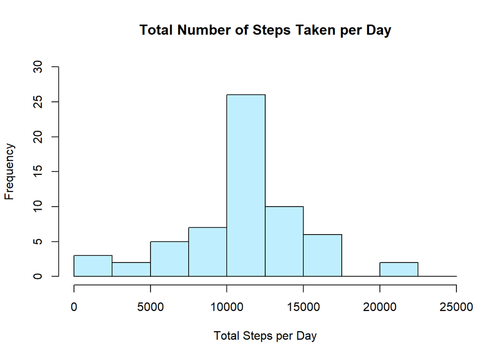

```r
hist(total_steps_imputed$daily_steps, main = "Total Number of Steps Taken per Day", xlab = "Total Steps per Day", col = "lightblue1", ylim = c(0,30), breaks = seq(0,25000, by=2500))
```

5. Calculate the new mean and median

```r
mean2 <- mean(total_steps_imputed$daily_steps)
median2 <- median(total_steps_imputed$daily_steps)
paste("The new mean number of steps taken per a day is", mean2)
```

```
## [1] "The new mean number of steps taken per a day is 10766.1886792453"
```

```r
paste("The new median number of steps taken per a day is", median2)
```

```
## [1] "The new median number of steps taken per a day is 10766.1886792453"
```

6. How are the histogram, mean, and median different from the original dataset?
   - The central bin on the histogram is larger and the mean and median are both higher
   - The mean and median are now the same number.

## Are there differences in activity patterns between weekdays and weekends?

1. Create a new factor variable in the dataset with two levels – “weekday” and “weekend” indicating whether a given date is a weekday or weekend day.

```r
activity$date <- as.Date(strptime(activity$date, format="%Y-%m-%d"))
activity$datetype <- sapply(activity$date, function(x) {
        if (weekdays(x) == "Saturday" | weekdays(x) == "Sunday")
                {y <- "Weekend"} else
                {y <- "Weekday"}
                y
        })
```

2. Make a panel plot containing a time series plot (i.e. type = "l") of the 5-minute interval (x-axis) and the average number of steps taken, averaged across all weekday days or weekend days (y-axis).

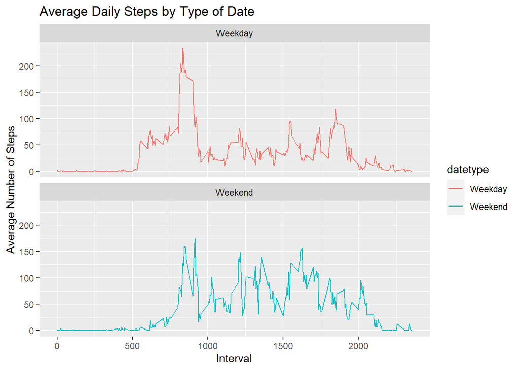

```r
activity_by_date <- with(activity, aggregate(steps~interval + datetype, FUN = mean, na.rm = TRUE))
plot<- ggplot(activity_by_date, aes(x = interval , y = steps, color = datetype)) +
       geom_line() +
       labs(title = "Average Daily Steps by Type of Date", x = "Interval", y = "Average Number of Steps") +
       facet_wrap(~datetype, ncol = 1, nrow=2)
print(plot)
```